# STAT 240 Project - Wage in Seattle

Kejun

2024-07-31

### Setup details

- This project use the following scripts, assumed to be in the course scripts directory.

  `../../scripts/ggprob.R`
- This project use the Seattle hourly wage data.

  `../data/City_of_Seattle_Wage_Data_20240723.csv`

## Introduction

- Seattle, located on the West Coast, has become an ideal destination for international students and potential immigrants seeking career opportunities. Among all the departments in Seattle, Information Technology (IT) department stands out as the highest paying department, within which information technology professionals and strategic advisors are the most promising positions.
- **Questions of interest:**
  - What are the best paying occupations in Seattle as of June 2024?
  - Is there a statistically significant difference in the proportion of high earners (those earning above the median hourly rate) between information technology professionals and strategic advisors within the Information Technology department in the City of Seattle as of June 2024?
- This analysis seeks to determine whether there is a statistically significant difference in the proportion of high earners between information technology professionals and strategic advisors. Understanding this difference can help STEM students make informed career decisions, especially who are interested in information technology.
- **Thesis Statement:** This report investigates the wage distribution among information technology professionals and strategic advisors in the city of Seattle’s IT department, aiming to identify significant differences in the proportion of high earners between these two job titles. By applying statistical inference, we assert that there is a distinction in earning potential between these two roles.

## Background

- The source of the data

## Part 1: The highest paying department

### Wage Analysis by Department

- Question: Which departments pay higher wages for their employees?
- As some positions have too few employees and not very representative, let’s only analyze positions with more than 200 people in the sample.

```
## # A tibble: 12 × 4
##    department                     count mean_hourly_rate median_hourly_rate
##    <chr>                          <int>            <dbl>              <dbl>
##  1 Information Technology           621             66.2               64
##  2 Police Department               1460             65.3               68.8
##  3 Construction & Inspections       433             59.5               58.8
##  4 Seattle City Light              1749             58.0               60.3
##  5 Fire Department                 1088             56.6               55.1
##  6 Seattle Dept of Transportation  1041             55.1               55.2
##  7 Finance & Admin Services         575             53.7               51.6
##  8 Seattle Public Utilities        1415             53.6               49.5
##  9 Human Services Department        420             49.1               45.9
## 10 Seattle Public Library           635             41.3               38.9
## 11 Seattle Center                   600             37.5               37.4
## 12 Parks & Recreation              1968             34.7               31.6
```

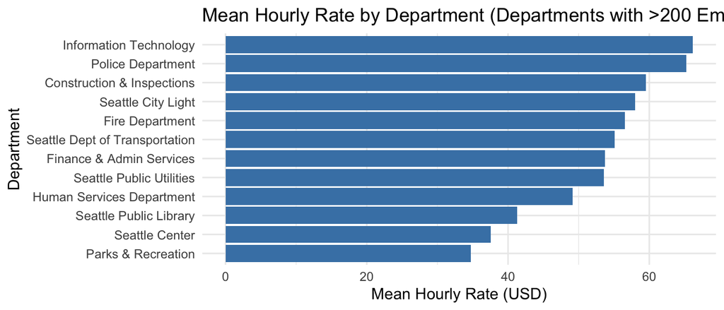

> Conclusion: The most money-making industry in Seattle is Information Technology, followed by the Police Department.

## Part 2: The highest occupations within IT department

### Inside IT Department

- Question: Inside the department with the highest wage, which positions are more promising?

```
## # A tibble: 49 × 4
##    job_title                  count mean_hourly_rate median_hourly_rate
##    <chr>                      <int>            <dbl>              <dbl>
##  1 Chief Technology Officer       1            153.               153.
##  2 Executive3                     4            117.               118.
##  3 Executive2                     8             98.8               97.4
##  4 Manager3,Info Technol          2             85.8               85.8
##  5 Executive1                     2             85.0               85.0
##  6 Manager3,Exempt                3             83.4               85.4
##  7 StratAdvsr3,Exempt             1             82.2               82.2
##  8 Info Technol Prof A,Exempt   116             80.7               80.8
##  9 Manager2,Fin,Bud,&Actg         1             77.5               77.5
## 10 Manager2,Exempt                1             73.5               73.5
## # ℹ 39 more rows
```

> As some positions in IT department have too few employees (such as executives), we only analyze positions with more than 5 people in the sample.

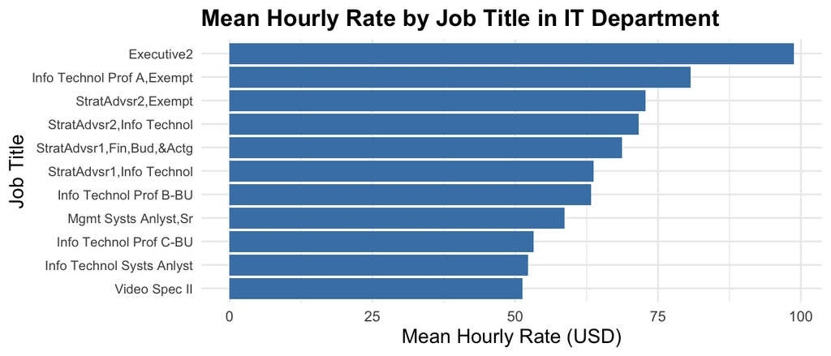

> Conclusion: Apart from executives, information technology professionals and strategic advisors also have competitive wages in IT department, with larger numbers of positions.

### Information Technology Professionals

> Examples of information technology professionals:
- Computer Programmer
- Software Engineer
- Computer Systems Analyst
- Computer Network Architect

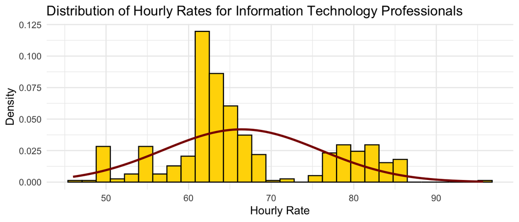

### Strategic Advisors

> What are strategic advisors?
- Strategic advisors apply a series of processes together with experience and data to enable the teams within an organization to make the best choices they are able to.

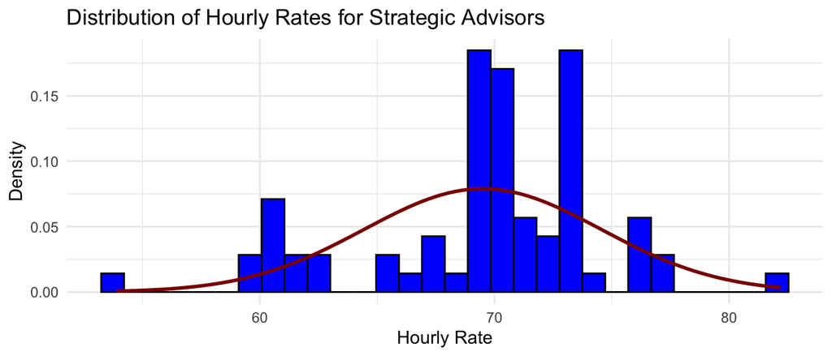

## Part 3: Hypothesis Testing

- The following is a hypothesis test to determine if there is a significant difference in the proportion of high earners (those earning above the median hourly rate) between Information Technology Professionals and Strategic Advisors.

### Statistical Model

- **Variables**
  - Y: The hourly wage of employees in the Information Technology department.
  - Z: A categorical variable indicating whether the job title is “Information Technology Professional” or “Strategic Advisor.”
  - Median: The median hourly wage for the Information Technology department.
  - X: A binary variable where X = 1 if an employee’s hourly wage is above the median hourly wage, and X = 0 otherwise.
- **Assumptions**
  - Independence: Each employee’s wage is independent of others’ wages.
  - Homogeneity: The probability of an employee being classified as a high earner (i.e., earning above the median hourly wage) is consistent within each job title category.
- **Hypothesis Testing**
  - Null Hypothesis (H0): There is no difference in the proportion of high earners between Information Technology Professionals and Strategic Advisors.
  - Alternative Hypothesis (H1): There is a difference in the proportion of high earners between Information Technology Professionals and Strategic Advisors.

#### Calculate Proportions:

Compute the proportion of high earners in groups of Information Technology Professionals and Strategic Advisors.

#### Agresti-Coull Confidence Intervals

```
## Agresti-Coull CI for Information Technology Professionals: 0.447652 0.539243
```

```
## Agresti-Coull CI for Strategic Advisors: 0.7308929 0.9020063
```

## Discussion

- The Agresti-Coull confidence interval for the proportion of high earners is [0.448,0.539]. This means we are 95% confident that the true proportion of high earners in the Information Technology Professionals group lies within this range.
- The Agresti-Coull confidence interval for the proportion of high earners is [0.731,0.902]. This indicates that we are 95% confident that the true proportion of high earners among Strategic Advisors falls within this interval.

> Interpretation:
- Information Technology Professionals: The proportion of high earners is relatively moderate.
- Strategic Advisors: The confidence interval is notably higher, indicating a greater proportion of high earners compared to the Information Technology Professionals.

## References

[^1] Retrieved from: https://www.linkedin.com/pulse/20140926120242-322046-what-does-a-strategic-advisor-actually-do/

[^2] Retrieved from: https://csuglobal.edu/blog/what-do-it-professionals-actually-do

[^1]: What are strategic advisors?
[^2]: Examples of information technology professionals